# 좋은 코드라는 블로그 글을 읽고

좋은 코드는 잘 읽히는 코드라는 다른 블로그 글을 봤는데, 아마 그럼 영어 네이티브가 유리하려나 라는 생각이 들었습니다.

[figure not shown]

개발을 잘 하고 싶다는 생각을 계속하고 있어서 관련 글도 열심히 찾아보고, 책도 열심히 뒤적뒤적하는 중이다. 이 와중에 [좋은 코드](https://sangminpark.blog/2021/05/28/%EC%A2%8B%EC%9D%80-%EC%BD%94%EB%93%9C/)라는 블로그 글을 보게 되었다.

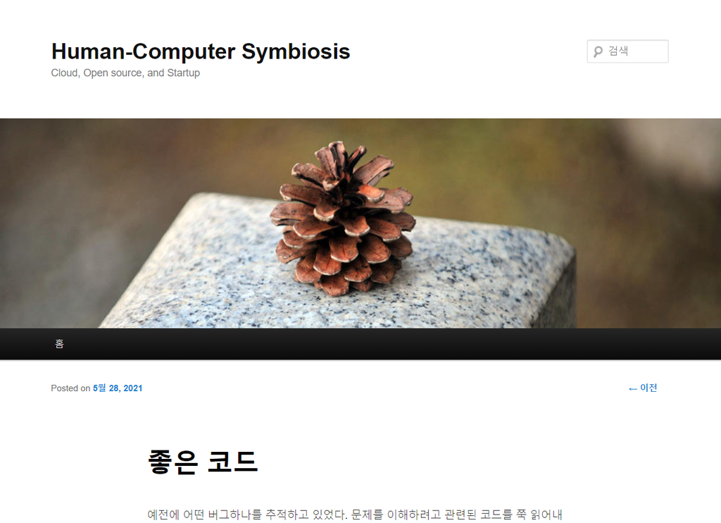

나에게 뼈때리는 문구를 발췌해보자면

> 대부분의 사람들은 동작하는 코드를 만들수 있다. 어떤 사람들은 <빠르게> 동작하는 코드를 만들수 있다. 그보다 적은 수의 사람들은 <이해할수 있는> 코드를 만든다.

어쩜 이렇게 명언들을 쏟아내셨는지.

> 코드를 만들때는 각자 자기의 성을 짓는것과 같다. 그런데 몇년후 자신이 만든 성에 들어가서도 우리는 길을 잃는다. 현실에서 회사는 남이 만든 초가집을 성이라 우기며 아름다운 탑을 몇개 더 붙이라고 요구한다.

블로그 주인님이 생각하는 좋은 코드에 대한 정의는 `당연하게 읽히는 코드` 라고 한다. 그 와중에 좋은 코드를 만든 사람의 예시도 들고, 반대의 경우도 설명한다.

> 이제 막 학교를 졸업한 어린이(?) 엔지니어들의 코드는 읽으면서 감탄사가 나온다. 여과해 <아 이딴식으로도 생각을 하는구나> 이 정도로 표현해야겠다.

이렇게 열심히 읽고 이해하려고 노력하다가 갑자기 생각이 들었다. OOP는 주어와 동사로 읽히는 문법을 표현하려고 노력한 걸거다. 한국어는 물건을 주어화하는 건 거의 없다. 영어는 꽤 있다고 알고 있다. 그럼 영어 네이티브인 사람들이 더 생각하기 수월하지 않을까? 다른 사람들이 어떻게 생각할지 궁금해서 글을 남겨둔다.